## Analysis of the data collected for experiment 2 in the CHI 2018 article:

## How Relevant are Incidental Power Poses for HCI?

## To explore the effects of using mixture priors

```r
library(rstan)
library(bridgesampling)
#library(rethinking)
library(tidybayes)
library(tidyverse)
library(magrittr)
library(matrixStats)
library(modelr)
library(broom)
library(shiny)
library(sm)
```

## Data

Load the data

```r
df <- read.csv("posture-master/data/exp2.csv")

df %<>%
  mutate(condition = condition == 'expansive')
```

## Stan models

Model 1: The first model is the BEST test model as described by Kruschke in the paper *Bayesian estimateion supersedes the t-test*. In this model, $\beta$ indicates the mean difference in the outcome variable between the two groups (in this case, the percent change in the BART scores). We fit different priors on $\beta$ and set different weights on these priors to obtain our posterior estimate.

$$y_{i} \sim \mathrm{T}(\nu, \mu, \sigma_y[x_i]) \\
\mu = \alpha_{0} + \beta * x_i \\
\beta \sim \mathrm{N}(\mu_{0}, \sigma_{0}) \\
\sigma_y \sim \mathrm{Cauchy}(0, 2) \\
\nu \sim \mathrm{exp}(30)$$

```stan
data{
    int<lower=1> N;
    int<lower=1> N_condition;
    real y[N];
    int condition[N];
    real y_bar; // observed mean of the outcome variable
    real prior_mu; // prior mean on the coefficient
    real prior_sigma; // prior stdev on the coefficient
}
parameters{
    real a_0;
    real b;
    real<lower=0> v;
    real b_sigma;
    real temp_sigma_Intercept;
}
model{
    vector[N] mu;
    vector[N] sigma;

    for ( i in 1:N ) {
        mu[i] = a_0 + b * condition[i];
        sigma[i] = temp_sigma_Intercept + b_sigma * condition[i];
    }

    //priors
    target += exponential_lpdf( v | 30 );
    target += cauchy_lpdf(b_sigma | 0, 2);
    target += cauchy_lpdf(temp_sigma_Intercept | 0, 2);
    target += normal_lpdf( b | prior_mu, prior_sigma );
    target += normal_lpdf( a_0 | y_bar, 10 );

    //likelihood
    target += student_t_lpdf( y | v , mu , sigma );
}
```

## Functions for generating mixture priors

Below, we have created the functions which can be used as a pipeline to get a data.frame of posterior samples computed using the mixture priors.

*fitted_single_models* takes in the data as a list, the compiled stan_model (of class “stanmodel”), and the priors as a data.frame, where each row corresponds to a set of priors for the model. It returns a posterior samples for each set of priors, and the marginal log-likelihood for each posterior. The log-likelihood is important for calculating the posterior weights.

```r
# data needs to be provided as a list
# priors need to be provided as a data.frame
fitted_single_models <- function(obs.data, stan_model, priors){
  mixture_models <- priors %>%
    nest(-j) %>%
    mutate(
      fit = map(data, ~ sampling(
      stan_model,
      data = compose_data(as.list(.), obs.data),
      iter = 10000,
      warmup = 1000,
      chain = 2,
      cores = 2
    ))) %>%
  unnest(data) %>%
  mutate(
    bs = map(fit, bridge_sampler, silent = TRUE),
    log_C = unlist(map(bs, "logml"))
  )

  return(mixture_models)
}

prior_post_model_densities <- function(fitted_models, grid, post_parameter){
  prior_densities <- fitted_models %>%
    mutate(
      j = as.factor(j),
      grid = list(grid)
    ) %>%
    unnest(grid) %>%
    mutate( prior_d = prior_f(grid, prior_mu, prior_sigma) )

  post_densities <- fitted_models %>%
    mutate(
      j = as.factor(j),
      posterior_estimates = map(fit, tidy_draws)
    ) %>%
    unnest(posterior_estimates) %>%
    select(j, post_parameter) %>%
    group_by(j) %>%
    nest(post_parameter) %>%
    mutate(
      d = map(data, ~post_f(grid, .x[[post_parameter]]))
    ) %>%
    unnest(d)

  return( left_join(prior_densities, post_densities) )
}

#Helper functions for calculating posterior densities
prior_f = function(grid, mu, sigma) {
  return(dnorm(grid, mu, sigma))
}

post_f = function(grid, data) {
  d = tibble(
    grid = grid,
    post_d = sm.density(data, h = 0.5, model = "epanechnikov", eval.points = grid, display = "none")$estimate
  )
  return(d)
}
```

### Calculating optimistic mean difference between the two conditions

To calculate the optimistic mean difference we use the effect size of risk-taking behavior. The original effect size estimate by Carney et. al. in the paper is ~0.6. This value was found here: http://www.slate.com/articles/health_and_science/science/2016/01/amy_cuddy_s_power_pose_research_is_the_latest_example_of_scientific_overreach.html

The meta-analytic standardized effect size estimate is ~0.2. Using this effect size, we can make an estimate for the mean for the optimistic priors

TO-DO: change this into a function

```r
# using mean number of pumps as the variable
sd_pooled.orig <- df %>%
  group_by(condition) %>%
  select(orig) %>%
  summarise( n = n(), sd = sd(orig) ) %>%
  mutate( d = (n-1)*sd^2 ) %>%
  summarise( n = sum(n), d = sum(d) ) %>%
  mutate( sd_pooled = sqrt(d / (n - 2)) ) %>%
  select(sd_pooled) %>%
  as.numeric(.)
# using % change as the variable
sd_pooled.change <- df %>%
  group_by(condition) %>%
  select(change) %>%
  summarise( n = n(), sd = sd(change) ) %>%
  mutate( d = (n-1)*sd^2 ) %>%
  summarise( n = sum(n), d = sum(d) ) %>%
  mutate( sd_pooled = sqrt(d / (n - 2)) ) %>%
  select(sd_pooled) %>%
  as.numeric(.)
#sd_pooled <- sd_pooled.orig # uncomment this to use orig as the variable instead
sd_pooled <- sd_pooled.change
mu.optim.1 <- floor(0.23 * sd_pooled) # expected mean difference, based on the meta-analytic estimate
mu.optim.2 <- floor(0.6 * sd_pooled) # expected mean difference, based on the Carney et. al.'s paper

mixture_priors <- data.frame(
  prior_mu = c(0, mu.optim.1, 0, mu.optim.1),
  prior_sigma = c(5, 5, 20, 20),
  prior_weight = c(0.25, 0.25, 0.25, 0.25)
) %>%
  mutate(
    j = seq.int(nrow(.))
  )

d.BEST <- list(
  N = nrow(df),
  N_condition = as.integer(length(unique(df$condition))),
  condition = as.integer(df$condition),
  sigma_condition = as.integer(ifelse(df$condition, 1, 2)),
  y = df$change, # change to 'orig' here
  y_bar = mean(df$change) # change to 'orig' here
)
```

```r
xgrid <- seq(-40, 40, length.out = 2000)

mixture.BEST <- d.BEST %>%
  fitted_single_models(bayes_est_model, mixture_priors)
mixture.BEST.densities <- mixture.BEST %>%
  prior_post_model_densities( xgrid, 'b')
mixture.BEST$fit
```

```
## [[1]]
## Inference for Stan model: 190954a546c1480c483e5a4d4ae08dd6.
## 2 chains, each with iter=10000; warmup=1000; thin=1;
## post-warmup draws per chain=9000, total post-warmup draws=18000.
##
##                         mean se_mean   sd    2.5%     25%     50%     75%
## a_0                    22.49    0.03 3.10   16.11   20.52   22.59   24.57
## b                      -4.97    0.03 3.80  -12.11   -7.56   -5.02   -2.48
## b_sigma                 1.15    0.03 3.24   -4.40   -0.69    0.71    2.54
## temp_sigma_Intercept   15.54    0.04 3.73    8.73   12.98   15.32   17.92
## lp__                 -459.08    0.02 1.79 -463.43 -460.02 -458.75 -457.76
##                        97.5% n_eff Rhat
## a_0                    28.41 11271    1
## b                       2.70 12694    1
## v                       0.88 13234    1
## b_sigma                 9.10  8767    1
## temp_sigma_Intercept   23.46  9727    1
## lp__                 -456.64  6603    1
##
## Samples were drawn using NUTS(diag_e) at Mon Sep  3 11:33:48 2018.
## For each parameter, n_eff is a crude measure of effective sample size,
## and Rhat is the potential scale reduction factor on split chains (at
## convergence, Rhat=1).
##
## [[2]]
## Inference for Stan model: 190954a546c1480c483e5a4d4ae08dd6.
## 2 chains, each with iter=10000; warmup=1000; thin=1;
## post-warmup draws per chain=9000, total post-warmup draws=18000.
##
##                         mean se_mean   sd    2.5%     25%     50%     75%
## a_0                    20.27    0.03 3.43   13.05   18.07   20.48   22.63
## b                       1.22    0.04 4.08   -6.49   -1.56    1.09    3.95
## b_sigma                 1.32    0.04 3.50   -4.23   -0.65    0.75    2.66
## temp_sigma_Intercept   16.71    0.04 3.86    9.57   14.08   16.56   19.16
## lp__                 -462.08    0.02 1.75 -466.27 -463.01 -461.75 -460.78
##                        97.5% n_eff Rhat
## a_0                    26.51 12282    1
## b                       9.45 12400    1
## v                       0.91 14646    1
## b_sigma                10.10  7161    1
```

[output cut: 40 more lines]

```
## b_sigma                 1.08    0.03 3.10   -4.40   -0.66    0.69    2.44
## temp_sigma_Intercept   15.15    0.03 3.68    8.54   12.59   14.93   17.49
## lp__                 -459.75    0.02 1.75 -463.98 -460.67 -459.43 -458.46
##                        97.5% n_eff Rhat
## a_0                    30.64 11557    1
## b                       1.08 11473    1
## v                       0.87 13954    1
## b_sigma                 8.52 10560    1
## temp_sigma_Intercept   22.84 11675    1
## lp__                 -457.35  6506    1
##
## Samples were drawn using NUTS(diag_e) at Mon Sep  3 11:33:56 2018.
## For each parameter, n_eff is a crude measure of effective sample size,
## and Rhat is the potential scale reduction factor on split chains (at
## convergence, Rhat=1).
```

```r
#write.csv(mixture.BEST.densities, "prior_posterior_density_estimates.csv")
```

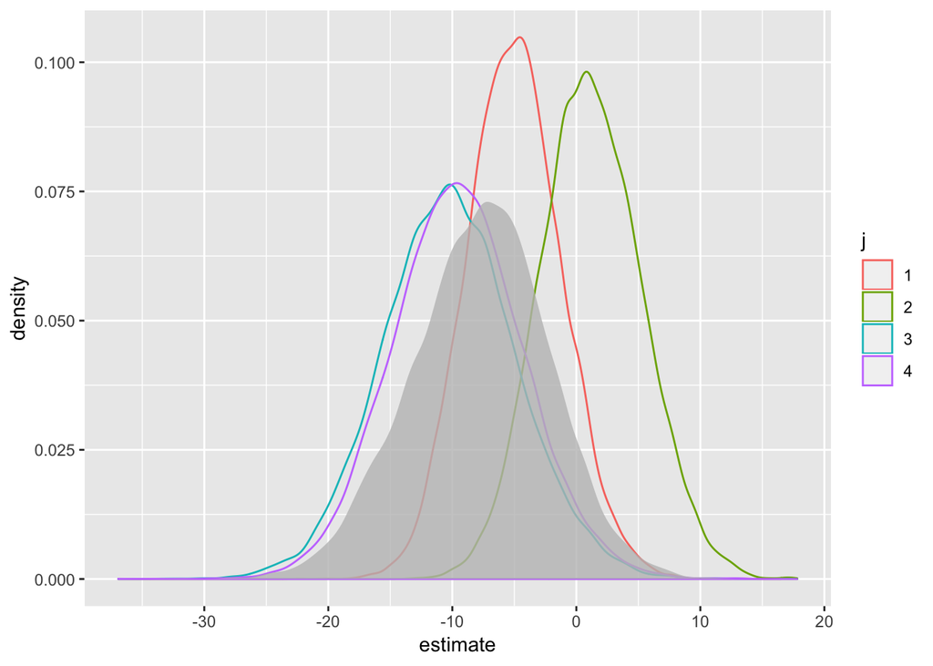

```r
estimates.BEST <- mixture.BEST %>%
  mutate(
    j = as.factor(j),
    posterior_estimates = map(fit, tidy_draws)
  ) %>%
  unnest(posterior_estimates) %>%
  mutate(
    estimate = b
  ) %>%
  select(j, prior_mu, prior_sigma, log_C, estimate)

mixture.BEST %>%
  mutate(
    prior_weight = c(0.25, 0.25, 0.25, 0.25), # change the weights here
    post_weight =  as.numeric(exp( log(prior_weight) + log_C - logSumExp(log(prior_weight) + log_C) )),
    posterior_estimates = map(fit, tidy_draws)
  ) %>%
  unnest(posterior_estimates) %>%
  mutate(
    estimate = b
  ) %>%
  sample_n(nrow(.)/max(.$j), weight = post_weight) %>%
  ggplot(aes(x = estimate)) +
  geom_density(data = estimates.BEST, aes(estimate, color = j)) +
  stat_density(fill = "gray75", alpha = 0.8)
```

```r
ui_norm <- fluidPage(
  sidebarLayout(
    sidebarPanel(
      sliderInput("weight.width", "Weight assigned to narrow prior (between wide and narrow priors)",
        min = 0, max = 1, value = 0.5
      ),
      sliderInput("weight.belief", "Weight assigned to skeptical prior (between optimistic and skeptical priors)",
        min = 0, max = 1, value = 0.5
      )
    ),
    mainPanel(
      plotOutput("distPlot")
    )
  )
)

server_norm <- function(input, output) {
  output$distPlot <- renderPlot({
    models <- mixture_models %>%
      mutate(
        j = as.factor(j),
        b = map(fit, spread_samples, b)
      ) %>%
      unnest(b) %>%
      select(j, b)

    mixture_models %>%
      mutate(prior_weight = c( (input$weight.width * input$weight.belief),
                               (input$weight.width * (1 - input$weight.belief)),
                               ((1 - input$weight.width) * input$weight.belief),
                               ((1 - input$weight.width) * (1 - input$weight.belief))
                            ),
        post_weight =  as.numeric(exp( log(prior_weight) + log_C - logSumExp(log(prior_weight) + log_C) )),
        posterior = map(fit, spread_samples, b)
      ) %>%
      unnest(posterior) %>%
      sample_n(nrow(.)/max(.$j), weight = post_weight) %>%
      ggplot(aes(x = b)) +
      stat_density(fill = "gray75") +
      geom_density(data = models, aes(b, color = j)) +
      geom_density(fill = "gray75", alpha = 0.7)
  })
}

shinyApp(ui_norm, server_norm)
```

Shiny applications not supported in static R Markdown documents